# Part 1:

# Question 1:

Please refer the table below to answer below questions

Planned to purchase || Product A Actually placed and order for Product A - Yes || Actually placed and order for Product A - No || Total

Yes || 400 || 100 || 500

No || 200 || 1300 || 1500

Total || 600 || 1400 || 2000

1. Refer to the above table and find the joint probability of the people who planned to purchase and actually placed an order.
2. Refer to the above table and find the joint probability of the people who planned to purchase and actually placed an order, given that people planned to purchase.

### 1.1 : Refer to the above table and find the joint probability of the people who planned to purchase and actually placed an order.

# Answer 1.1 :

```
Probablity = People who planned to puschase and actually placed the order / Total number of people

People who planned to puschase and actually placed the order = 400

Total number of people = 2000
Probablity = 400/2000
```

```python
People_planned_purchased = 400
Total_people = 2000
Probability1 = People_planned_purchased/Total_people
Probability1
print('Probability of the people who planned to purchase and actually placed an order is - '+str(Probability1*100)+'%')
```

```
Probability of the people who planned to purchase and actually placed an order is - 20.0%
```

# Question 1.2:

```
Refer to the above table and find the joint probability of the people who planned to purchase and actually placed an order, given that people planned to purchase.
```

# Answer 1.2:

```
Probablity = People who planned to puschase and actually placed the order / Total number of people given that peple have planned to purchase

People who planned to puschase and actually placed the order = 400

Total number of people given that peple have planned to purchase = 500

Probablity = 400/500 = .8 (i.e. 80 %)
```

```python
People_planned_purchased = 400
Total_People_given_planned = 500
Probability2 = People_planned_purchased/Total_People_given_planned
Probability2
print('Probability of the people who planned to purchase and actually placed an order, given that people planned to purchase - '+str(Probability2*100)+'%')
```

```
Probability of the people who planned to purchase and actually placed an order, given that people planned to purchase - 80.0%
```

=========================================================================================================================

# Question 2:

An electrical manufacturing company conducts quality checks at specified periods on the products it manufactures. Historically, the failure rate for the manufactured item is 5%. Suppose a random sample of 10 manufactured items is selected. Answer the following questions.

A. Probability that none of the items are defective?

B. Probability that exactly one of the items is defective?

C. Probability that two or fewer of the items are defective?

D. Probability that three or more of the items are defective ?

```python
import numpy as np
import scipy.stats as stats
import matplotlib.pyplot as plt
```

```python
p=.05 #failure rate
n=10
k=np.arange(0,n+1)
```

```python
binomial_ind = stats.binom.pmf(k,n,p)
binomial_cum = stats.binom.cdf(k,n,p)
```

```python
binomial_ind
```

```
array([5.98736939e-01, 3.15124705e-01, 7.46347985e-02, 1.04750594e-02,
       9.64808106e-04, 6.09352488e-05, 2.67259863e-06, 8.03789063e-08,
       1.58642578e-09, 1.85546875e-11, 9.76562500e-14])
```

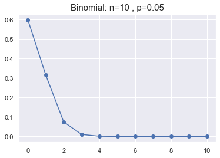

```python
plt.plot(k,binomial_ind,'o-')
plt.title('Binomial: n=%i , p=%.2f' % (n,p), fontsize=15)
plt.show()
```

```python
binomial_cum
```

```
array([0.59873694, 0.91386164, 0.98849644, 0.9989715 , 0.99993631,
       0.99999725, 0.99999992, 1.        , 1.        , 1.        ,
       1.        ])
```

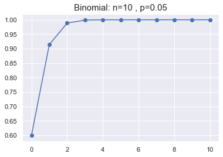

```python
plt.plot(k,binomial_cum,'o-')
plt.title('Binomial: n=%i , p=%.2f' % (n,p), fontsize=15)
plt.show()
```

# Question 2A.

```
Probability that none of the items are defective?
```

```python
binomial_ind[0]
```

```
0.5987369392383789
```

```python
print("Probability that none of the items are defective = " + str(binomial_ind[0]*100)+' %')
```

```
Probability that none of the items are defective = 59.87369392383789 %
```

# Answer 2A:

```
Probability that none of the items are defective = 59.87369392383789 %
```

# Question 2B.

```
Probability that exactly one of the items is defective?
```

```python
binomial_ind[1]
```

```
0.31512470486230504
```

```python
print("Probability that exactly one of the items is defective = " + str(binomial_ind[1]*100)+' %')
```

```
Probability that exactly one of the items is defective = 31.512470486230505 %
```

# Answer 2B:

```
Probability that exactly one of the items is defective = 31.512470486230505 %
```

# Question 2C.

```
Probability that two or fewer of the items are defective?
```

```python
binomial_cum[2]
```

```
0.9884964426207031
```

```python
print("Probability that two or fewer of the items are defective = " + str(binomial_cum[2]*100)+' %')
```

```
Probability that two or fewer of the items are defective = 98.84964426207031 %
```

# Answer 2C:

```
Probability that two or fewer of the items are defective = 98.84964426207031 %
```

# Question 2D:

```
Probability that three or more of the items are defective ?
```

```python
1 - binomial_cum[2]
```

```
0.01150355737929687
```

```python
print("Probability that three or more of the items are defective = " + str((1-binomial_cum[2])*100)+' %')
```

```
Probability that three or more of the items are defective = 1.150355737929687 %
```

# Answer 2D:

```
Probability that three or more of the items are defective = 1.150355737929687 %
```

=======================================================================================================================

# Question 3: A car salesman sells on an average 3 cars per week.

A. Probability that in a given week he will sell some cars.

B. Probability that in a given week he will sell 2 or more but less than 5 cars.

C. Plot the poisson distribution function for cumulative probability of cars sold per-week vs number of cars sold perweek.

```python
# A car salesman sells on an average 3 cars per week
rate = 3
```

```python
n1=np.arange(0,20)
```

```python
poisson_ind = stats.poisson.pmf(n1,rate)
poisson_ind
```

```
array([4.97870684e-02, 1.49361205e-01, 2.24041808e-01, 2.24041808e-01,
       1.68031356e-01, 1.00818813e-01, 5.04094067e-02, 2.16040315e-02,
       8.10151179e-03, 2.70050393e-03, 8.10151179e-04, 2.20950322e-04,
       5.52375804e-05, 1.27471339e-05, 2.73152870e-06, 5.46305740e-07,
       1.02432326e-07, 1.80762929e-08, 3.01271548e-09, 4.75691918e-10])
```

```python
poisson_cum = stats.poisson.cdf(n1,rate)
poisson_cum
```

```
array([0.04978707, 0.19914827, 0.42319008, 0.64723189, 0.81526324,
       0.91608206, 0.96649146, 0.9880955 , 0.99619701, 0.99889751,
       0.99970766, 0.99992861, 0.99998385, 0.9999966 , 0.99999933,
       0.99999988, 0.99999998, 1.        , 1.        , 1.        ])
```

# Question 3A.

```
Probability that in a given week he will sell some cars.
```

```python
1 - poisson_cum[0]
```

```
0.950212931632136
```

```python
print("Probability that in a given week he will sell some cars. = " + str((1 - poisson_cum[0])*100)+' %')
```

```
Probability that in a given week he will sell some cars. = 95.0212931632136 %
```

# Answer 3A:

```
Probability that in a given week he will sell some cars. = 0.950212931632136
```

# Question 3B.

[output not shown]

```python
poisson_cum[4] - poisson_cum[1]
```

```
0.6161149710523164
```

```python
print("Probability that in a given week he will sell some cars. = " + str((poisson_cum[4] - poisson_cum[1])*100)+' %')
```

```
Probability that in a given week he will sell some cars. = 61.611497105231635 %
```

# Answer 3B:

[output not shown]

# Question 3C.

```
Plot the poisson distribution function for cumulative probability of cars sold per-week vs number of cars sold perweek.
```

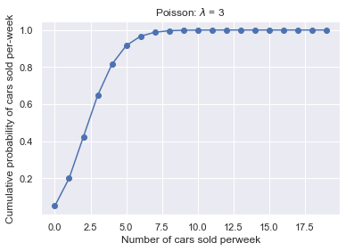

```python
plt.plot(n1,poisson_cum,'o-')
plt.title('Poisson: $\lambda$ = %i ' % rate)
plt.xlabel('Number of cars sold perweek')
plt.ylabel('Cumulative probability of cars sold per-week')
plt.show()
```

# Answer 3C:

```
Above graph shows poisson distribution function for cumulative probability of cars sold per-week vs number of cars sold perweek
```

========================================================================================================================

# Question 4:

Accuracy in understanding orders for a speech based bot at a restaurant is important for the Company X which has designed, marketed and launched the product for a contactless delivery due to the COVID-19 pandemic. Recognition accuracy that measures the percentage of orders that are taken correctly is 86.8%. Suppose that you place order with the bot and two friends of yours independently place orders with the same bot. Answer the following questions.

A. What is the probability that all three orders will be recognised correctly?

B. What is the probability that none of the three orders will be recognised correctly?

C. What is the probability that at least two of the three orders will be recognised correctly?

```python
import numpy as np
import scipy.stats as stats
import matplotlib.pyplot as plt
```

```python
n=3
p=.868
k=np.arange(0,4)
```

```python
order_binom_ind = stats.binom.pmf(k,n,p)
order_binom_cum = stats.binom.cdf(k,n,p)
```

```python
order_binom_ind
```

```
array([0.00229997, 0.0453721 , 0.2983559 , 0.65397203])
```

```python
order_binom_cum
```

```
array([0.00229997, 0.04767206, 0.34602797, 1.        ])
```

# Question 4A:

```
A. What is the probability that all three orders will be recognised correctly?
```

```python
# All three together
order_binom_ind[3]
```

```
0.653972032
```

```python
print("Probability that all three orders will be recognised correctly = " + str(order_binom_ind[3]*100)+' %')
```

```
Probability that all three orders will be recognised correctly = 65.39720319999999 %
```

# Answer 4A:

```
Probability that all three orders will be recognised correctly = 65.39720319999999 %
```

# Question 4B:

```
What is the probability that none of the three orders will be recognised correctly?
```

```python
# none of the three orders
order_binom_ind[0]
```

```
0.002299968
```

```python
print("Probability that none of the three orders will be recognised correctly = " + str(order_binom_ind[0]*100)+' %')
```

```
Probability that none of the three orders will be recognised correctly = 0.2299968 %
```

# Answer 4B:

```
Probability that none of the three orders will be recognised correctly = 0.2299968 %
```

# Question 4C:

```
What is the probability that at least two of the three orders will be recognised correctly?
```

```python
1 - order_binom_cum[1]
```

```
0.952327936
```

```python
print("Probability that at least two of the three orders will be recognised correctly = " + str((1 - order_binom_cum[1])*100) + ' %')
```

```
Probability that at least two of the three orders will be recognised correctly = 95.2327936 %
```

# Answer 4C:

```
Probability that at least two of the three orders will be recognised correctly = 95.2327936 %
```

=========================================================================================================================

# Question 5:

A group of 300 professionals sat for a competitive exam. The results show the information of marks obtained by them have a mean of 60 and a standard deviation of 12. The pattern of marks follows a normal distribution. Answer the following questions.

A. What is the percentage of students who score more than 80.

B. What is the percentage of students who score less than 50.

C. What should be the distinction mark if the highest 10% of students are to be awarded distinction?

```python
import numpy as np
import scipy.stats as stats
import matplotlib.pyplot as plt
```

# Question 5A.

```
What is the percentage of students who score more than 80.
```

```python
x = 1-stats.norm.cdf(80,loc=60,scale=12)
x
```

```
0.047790352272814696
```

```python
print('Percentage of students who score more than 80 is : '+str(x*100)+' %')
```

```
Percentage of students who score more than 80 is : 4.77903522728147 %
```

# Answer 5A:

```
Percentage of students who score more than 80 is : 4.77903522728147 %
```

# Question 5B:

```
What is the percentage of students who score less than 50?
```

```python
y = stats.norm.cdf(50,loc=60,scale=12)
y
```

```
0.20232838096364308
```

```python
print('Percentage of students who score less than 50 is : '+str(y*100)+' %')
```

```
Percentage of students who score less than 50 is : 20.232838096364308 %
```

# Answer 5B:

```
Percentage of students who score less than 50 is : 20.232838096364308 %
```

# Question 5C:

```
What should be the distinction mark if the highest 10% of students are to be awarded distinction?
```

```python
z=stats.norm.ppf(.90,60,12)
z
```

```
75.3786187865352
```

```python
print('Distinction mark if the highest 10% of students are to be awarded distinction is : '+str(z))
```

```
Distinction mark if the highest 10% of students are to be awarded distinction is : 75.3786187865352
```

# Answer 5C:

```
Distinction mark if the highest 10% of students are to be awarded distinction is : 75.3786187865352
```

==================================================================================================================

# Part 2:

• DOMAIN: Sports

• CONTEXT: Company X manages the men's top professional basketball division of the American league system. The dataset contains information on all the teams that have participated in all the past tournaments. It has data about how many baskets each team scored, conceded, how many times they came within the first 2 positions, how many tournaments they have qualified, their best position in the past, etc.

• DATA DESCRIPTION: Basketball.csv - The data set contains information on all the teams so far participated in all the past tournaments.

• ATTRIBUTE INFORMATION:

1. Team: Team’s name
2. Tournament: Number of played tournaments.
3. Score: Team’s score so far.
4. PlayedGames: Games played by the team so far.
5. WonGames: Games won by the team so far.
6. DrawnGames: Games drawn by the team so far.
7. LostGames: Games lost by the team so far.
8. BasketScored: Basket scored by the team so far.
9. BasketGiven: Basket scored against the team so far.
10. TournamentChampion: How many times the team was a champion of the tournaments so far.
11. Runner-up: How many times the team was a runners-up of the tournaments so far.
12. TeamLaunch: Year the team was launched on professional basketball.
13. HighestPositionHeld: Highest position held by the team amongst all the tournaments played.

• PROJECT OBJECTIVE: Company’s management wants to invest on proposal on managing some of the best teams in the league. The analytics department has been assigned with a task of creating a report on the performance shown by the teams. Some of the older teams are already in contract with competitors. Hence Company X wants to understand which teams they can approach which will be a deal win for them.

```python
import numpy as np
import pandas as pd
import seaborn as sns
import matplotlib.pyplot as plt  # seaborn is based on matplotlib
sns.set(color_codes=True) # adds a nice background to the graphs
%matplotlib inline
```

```python
mydata = pd.read_csv('DS - Part2 - Basketball.csv')
```

```python
mydata.head()
```

|  | Team | Tournament | Score | PlayedGames | WonGames | DrawnGames | LostGames | BasketScored | BasketGiven | TournamentChampion | Runner-up | TeamLaunch | HighestPositionHeld |
| --- | --- | --- | --- | --- | --- | --- | --- | --- | --- | --- | --- | --- | --- |
| 0 | Team 1 | 86 | 4385 | 2762 | 1647 | 552 | 563 | 5947 | 3140 | 33 | 23 | 1929 | 1 |
| 1 | Team 2 | 86 | 4262 | 2762 | 1581 | 573 | 608 | 5900 | 3114 | 25 | 25 | 1929 | 1 |
| 2 | Team 3 | 80 | 3442 | 2614 | 1241 | 598 | 775 | 4534 | 3309 | 10 | 8 | 1929 | 1 |
| 3 | Team 4 | 82 | 3386 | 2664 | 1187 | 616 | 861 | 4398 | 3469 | 6 | 6 | 1931to32 | 1 |
| 4 | Team 5 | 86 | 3368 | 2762 | 1209 | 633 | 920 | 4631 | 3700 | 8 | 7 | 1929 | 1 |

```python
mydata.tail()
```

|  | Team | Tournament | Score | PlayedGames | WonGames | DrawnGames | LostGames | BasketScored | BasketGiven | TournamentChampion | Runner-up | TeamLaunch | HighestPositionHeld |
| --- | --- | --- | --- | --- | --- | --- | --- | --- | --- | --- | --- | --- | --- |
| 56 | Team 57 | 1 | 34 | 38 | 8 | 10 | 20 | 38 | 66 | - | - | 2009-10 | 20 |
| 57 | Team 58 | 1 | 22 | 30 | 7 | 8 | 15 | 37 | 57 | - | - | 1956-57 | 16 |
| 58 | Team 59 | 1 | 19 | 30 | 7 | 5 | 18 | 51 | 85 | - | - | 1951~52 | 16 |
| 59 | Team 60 | 1 | 14 | 30 | 5 | 4 | 21 | 34 | 65 | - | - | 1955-56 | 15 |
| 60 | Team 61 | 1 | - | - | - | - | - | - | - | - | - | 2017~18 | 9 |

```python
mydata.describe(include="all")
```

|  | Team | Tournament | Score | PlayedGames | WonGames | DrawnGames | LostGames | BasketScored | BasketGiven | TournamentChampion | Runner-up | TeamLaunch | HighestPositionHeld |
| --- | --- | --- | --- | --- | --- | --- | --- | --- | --- | --- | --- | --- | --- |
| count | 61 | 61.000000 | 61 | 61 | 61 | 61 | 61 | 61 | 61 | 61 | 61 | 61 | 61.000000 |
| unique | 61 | NaN | 61 | 53 | 59 | 57 | 56 | 60 | 61 | 8 | 10 | 47 | NaN |
| top | Team 40 | NaN | 190 | 2762 | 8 | 16 | 37 | 70 | 1157 | - | - | 1929 | NaN |
| freq | 1 | NaN | 1 | 3 | 2 | 2 | 3 | 2 | 1 | 52 | 48 | 10 | NaN |
| mean | NaN | 24.000000 | NaN | NaN | NaN | NaN | NaN | NaN | NaN | NaN | NaN | NaN | 7.081967 |
| std | NaN | 26.827225 | NaN | NaN | NaN | NaN | NaN | NaN | NaN | NaN | NaN | NaN | 5.276663 |
| min | NaN | 1.000000 | NaN | NaN | NaN | NaN | NaN | NaN | NaN | NaN | NaN | NaN | 1.000000 |
| 25% | NaN | 4.000000 | NaN | NaN | NaN | NaN | NaN | NaN | NaN | NaN | NaN | NaN | 3.000000 |
| 50% | NaN | 12.000000 | NaN | NaN | NaN | NaN | NaN | NaN | NaN | NaN | NaN | NaN | 6.000000 |
| 75% | NaN | 38.000000 | NaN | NaN | NaN | NaN | NaN | NaN | NaN | NaN | NaN | NaN | 10.000000 |
| max | NaN | 86.000000 | NaN | NaN | NaN | NaN | NaN | NaN | NaN | NaN | NaN | NaN | 20.000000 |

```python
mydata.info()
```

```
<class 'pandas.core.frame.DataFrame'>
RangeIndex: 61 entries, 0 to 60
Data columns (total 13 columns):
 #   Column               Non-Null Count  Dtype
---  ------               --------------  -----
 0   Team                 61 non-null     object
 1   Tournament           61 non-null     int64
 2   Score                61 non-null     object
 3   PlayedGames          61 non-null     object
 4   WonGames             61 non-null     object
 5   DrawnGames           61 non-null     object
 6   LostGames            61 non-null     object
 7   BasketScored         61 non-null     object
 8   BasketGiven          61 non-null     object
 9   TournamentChampion   61 non-null     object
 10  Runner-up            61 non-null     object
 11  TeamLaunch           61 non-null     object
 12  HighestPositionHeld  61 non-null     int64
dtypes: int64(2), object(11)
memory usage: 6.3+ KB
```

### Clean the data and prepare a final dataset to be used for analysis

```python
# Cleairng is required because because there are entries in which are with '-'
# possible solution is too replace the '-' with '0'
# once this is done, Columsn will be converted to Float as required
```

```python
mydata = mydata.replace(['-'],'0')
mydata['Score'] = mydata['Score'].astype(int)
mydata['PlayedGames'] = mydata['PlayedGames'].astype(int)
mydata['WonGames'] = mydata['WonGames'].astype(int)
mydata['DrawnGames'] = mydata['DrawnGames'].astype(int)
mydata['LostGames'] = mydata['LostGames'].astype(int)
mydata['BasketScored'] = mydata['BasketScored'].astype(int)
mydata['BasketGiven'] = mydata['BasketGiven'].astype(int)
mydata['TournamentChampion'] = mydata['TournamentChampion'].astype(int)
mydata['Runner-up'] = mydata['Runner-up'].astype(int)
mydata['TeamLaunch'] = mydata['TeamLaunch'].str[:4]
mydata.describe(include="all")
```

|  | Team | Tournament | Score | PlayedGames | WonGames | DrawnGames | LostGames | BasketScored | BasketGiven | TournamentChampion | Runner-up | TeamLaunch | HighestPositionHeld |
| --- | --- | --- | --- | --- | --- | --- | --- | --- | --- | --- | --- | --- | --- |
| count | 61 | 61.000000 | 61.000000 | 61.000000 | 61.000000 | 61.000000 | 61.000000 | 61.000000 | 61.000000 | 61.000000 | 61.000000 | 61 | 61.000000 |
| unique | 61 | NaN | NaN | NaN | NaN | NaN | NaN | NaN | NaN | NaN | NaN | 45 | NaN |
| top | Team 40 | NaN | NaN | NaN | NaN | NaN | NaN | NaN | NaN | NaN | NaN | 1929 | NaN |
| freq | 1 | NaN | NaN | NaN | NaN | NaN | NaN | NaN | NaN | NaN | NaN | 10 | NaN |
| mean | NaN | 24.000000 | 901.426230 | 796.819672 | 303.967213 | 188.934426 | 303.754098 | 1140.344262 | 1140.229508 | 1.426230 | 1.409836 | NaN | 7.081967 |
| std | NaN | 26.827225 | 1134.899121 | 876.282765 | 406.991030 | 201.799477 | 294.708594 | 1506.740211 | 1163.710766 | 5.472535 | 4.540107 | NaN | 5.276663 |
| min | NaN | 1.000000 | 0.000000 | 0.000000 | 0.000000 | 0.000000 | 0.000000 | 0.000000 | 0.000000 | 0.000000 | 0.000000 | NaN | 1.000000 |
| 25% | NaN | 4.000000 | 96.000000 | 114.000000 | 34.000000 | 24.000000 | 62.000000 | 153.000000 | 221.000000 | 0.000000 | 0.000000 | NaN | 3.000000 |
| 50% | NaN | 12.000000 | 375.000000 | 423.000000 | 123.000000 | 95.000000 | 197.000000 | 430.000000 | 632.000000 | 0.000000 | 0.000000 | NaN | 6.000000 |
| 75% | NaN | 38.000000 | 1351.000000 | 1318.000000 | 426.000000 | 330.000000 | 563.000000 | 1642.000000 | 1951.000000 | 0.000000 | 0.000000 | NaN | 10.000000 |
| max | NaN | 86.000000 | 4385.000000 | 2762.000000 | 1647.000000 | 633.000000 | 1070.000000 | 5947.000000 | 3889.000000 | 33.000000 | 25.000000 | NaN | 20.000000 |

```python
mydata.info()
```

```
<class 'pandas.core.frame.DataFrame'>
RangeIndex: 61 entries, 0 to 60
Data columns (total 13 columns):
 #   Column               Non-Null Count  Dtype
---  ------               --------------  -----
 0   Team                 61 non-null     object
 1   Tournament           61 non-null     int64
 2   Score                61 non-null     int32
 3   PlayedGames          61 non-null     int32
 4   WonGames             61 non-null     int32
 5   DrawnGames           61 non-null     int32
 6   LostGames            61 non-null     int32
 7   BasketScored         61 non-null     int32
 8   BasketGiven          61 non-null     int32
 9   TournamentChampion   61 non-null     int32
 10  Runner-up            61 non-null     int32
 11  TeamLaunch           61 non-null     object
 12  HighestPositionHeld  61 non-null     int64
dtypes: int32(9), int64(2), object(2)
memory usage: 4.2+ KB
```

```python
mydata1 = mydata
```

```python
mydata1.info()
```

```
<class 'pandas.core.frame.DataFrame'>
RangeIndex: 61 entries, 0 to 60
Data columns (total 13 columns):
 #   Column               Non-Null Count  Dtype
---  ------               --------------  -----
 0   Team                 61 non-null     object
 1   Tournament           61 non-null     int64
 2   Score                61 non-null     int32
 3   PlayedGames          61 non-null     int32
 4   WonGames             61 non-null     int32
 5   DrawnGames           61 non-null     int32
 6   LostGames            61 non-null     int32
 7   BasketScored         61 non-null     int32
 8   BasketGiven          61 non-null     int32
 9   TournamentChampion   61 non-null     int32
 10  Runner-up            61 non-null     int32
 11  TeamLaunch           61 non-null     object
 12  HighestPositionHeld  61 non-null     int64
dtypes: int32(9), int64(2), object(2)
memory usage: 4.2+ KB
```

### 2.2 - Perform detailed statistical analysis and EDA using univariate, bi-variate and multivariate EDA techniques to get a data driven insights on recommending which teams they can approach which will be a deal win for them.. Also as a data and statistics expert you have to develop a detailed performance report using this data.

### Hint: Use statistical techniques and visualisation techniques to come up with useful metrics and reporting. Find out the best performing team, oldest team, team with highest goals, team with lowest performance etc. and many more. These are just random examples please use your best analytical approach to build this report. You can mix match columns to create new ones which can be used for better analysis. Create your own features if required. Be highly experimental and analytical here to find hidden patterns. Use graphical interactive libraries to enable you to publish interactive plots in python.

```python
# team who won the maximum matches
mydata[mydata.WonGames ==mydata.WonGames.max()]
```

|  | Team | Tournament | Score | PlayedGames | WonGames | DrawnGames | LostGames | BasketScored | BasketGiven | TournamentChampion | Runner-up | TeamLaunch | HighestPositionHeld |
| --- | --- | --- | --- | --- | --- | --- | --- | --- | --- | --- | --- | --- | --- |
| 0 | Team 1 | 86 | 4385 | 2762 | 1647 | 552 | 563 | 5947 | 3140 | 33 | 23 | 1929 | 1 |

```python
mydata.sort_values(by = 'WonGames', ascending=False).head()
```

|  | Team | Tournament | Score | PlayedGames | WonGames | DrawnGames | LostGames | BasketScored | BasketGiven | TournamentChampion | Runner-up | TeamLaunch | HighestPositionHeld |
| --- | --- | --- | --- | --- | --- | --- | --- | --- | --- | --- | --- | --- | --- |
| 0 | Team 1 | 86 | 4385 | 2762 | 1647 | 552 | 563 | 5947 | 3140 | 33 | 23 | 1929 | 1 |
| 1 | Team 2 | 86 | 4262 | 2762 | 1581 | 573 | 608 | 5900 | 3114 | 25 | 25 | 1929 | 1 |
| 2 | Team 3 | 80 | 3442 | 2614 | 1241 | 598 | 775 | 4534 | 3309 | 10 | 8 | 1929 | 1 |
| 4 | Team 5 | 86 | 3368 | 2762 | 1209 | 633 | 920 | 4631 | 3700 | 8 | 7 | 1929 | 1 |
| 3 | Team 4 | 82 | 3386 | 2664 | 1187 | 616 | 861 | 4398 | 3469 | 6 | 6 | 1931 | 1 |

### Team 1, Team 2 and team 3 are top team who won the most number of matches

```python
# team who scored maximum points
mydata[mydata.Score ==mydata.Score.max()]
```

|  | Team | Tournament | Score | PlayedGames | WonGames | DrawnGames | LostGames | BasketScored | BasketGiven | TournamentChampion | Runner-up | TeamLaunch | HighestPositionHeld |
| --- | --- | --- | --- | --- | --- | --- | --- | --- | --- | --- | --- | --- | --- |
| 0 | Team 1 | 86 | 4385 | 2762 | 1647 | 552 | 563 | 5947 | 3140 | 33 | 23 | 1929 | 1 |

```python
mydata.sort_values(by = 'Score', ascending=False).head()
```

|  | Team | Tournament | Score | PlayedGames | WonGames | DrawnGames | LostGames | BasketScored | BasketGiven | TournamentChampion | Runner-up | TeamLaunch | HighestPositionHeld |
| --- | --- | --- | --- | --- | --- | --- | --- | --- | --- | --- | --- | --- | --- |
| 0 | Team 1 | 86 | 4385 | 2762 | 1647 | 552 | 563 | 5947 | 3140 | 33 | 23 | 1929 | 1 |
| 1 | Team 2 | 86 | 4262 | 2762 | 1581 | 573 | 608 | 5900 | 3114 | 25 | 25 | 1929 | 1 |
| 2 | Team 3 | 80 | 3442 | 2614 | 1241 | 598 | 775 | 4534 | 3309 | 10 | 8 | 1929 | 1 |
| 3 | Team 4 | 82 | 3386 | 2664 | 1187 | 616 | 861 | 4398 | 3469 | 6 | 6 | 1931 | 1 |
| 4 | Team 5 | 86 | 3368 | 2762 | 1209 | 633 | 920 | 4631 | 3700 | 8 | 7 | 1929 | 1 |

```python
# team who was TournamentChampion maximum no of times
mydata[mydata.TournamentChampion ==mydata.TournamentChampion.max()]
```

|  | Team | Tournament | Score | PlayedGames | WonGames | DrawnGames | LostGames | BasketScored | BasketGiven | TournamentChampion | Runner-up | TeamLaunch | HighestPositionHeld |
| --- | --- | --- | --- | --- | --- | --- | --- | --- | --- | --- | --- | --- | --- |
| 0 | Team 1 | 86 | 4385 | 2762 | 1647 | 552 | 563 | 5947 | 3140 | 33 | 23 | 1929 | 1 |

```python
mydata.sort_values(by = 'TournamentChampion', ascending=False).head()
```

|  | Team | Tournament | Score | PlayedGames | WonGames | DrawnGames | LostGames | BasketScored | BasketGiven | TournamentChampion | Runner-up | TeamLaunch | HighestPositionHeld |
| --- | --- | --- | --- | --- | --- | --- | --- | --- | --- | --- | --- | --- | --- |
| 0 | Team 1 | 86 | 4385 | 2762 | 1647 | 552 | 563 | 5947 | 3140 | 33 | 23 | 1929 | 1 |
| 1 | Team 2 | 86 | 4262 | 2762 | 1581 | 573 | 608 | 5900 | 3114 | 25 | 25 | 1929 | 1 |
| 2 | Team 3 | 80 | 3442 | 2614 | 1241 | 598 | 775 | 4534 | 3309 | 10 | 8 | 1929 | 1 |
| 4 | Team 5 | 86 | 3368 | 2762 | 1209 | 633 | 920 | 4631 | 3700 | 8 | 7 | 1929 | 1 |
| 3 | Team 4 | 82 | 3386 | 2664 | 1187 | 616 | 861 | 4398 | 3469 | 6 | 6 | 1931 | 1 |

### Team 1, Team 2 and team 3 are top teams who have won maximum no of tournaments

```python
# team who are oldest
mydata[mydata.TeamLaunch == mydata.TeamLaunch.min()]
```

|  | Team | Tournament | Score | PlayedGames | WonGames | DrawnGames | LostGames | BasketScored | BasketGiven | TournamentChampion | Runner-up | TeamLaunch | HighestPositionHeld |
| --- | --- | --- | --- | --- | --- | --- | --- | --- | --- | --- | --- | --- | --- |
| 0 | Team 1 | 86 | 4385 | 2762 | 1647 | 552 | 563 | 5947 | 3140 | 33 | 23 | 1929 | 1 |
| 1 | Team 2 | 86 | 4262 | 2762 | 1581 | 573 | 608 | 5900 | 3114 | 25 | 25 | 1929 | 1 |
| 2 | Team 3 | 80 | 3442 | 2614 | 1241 | 598 | 775 | 4534 | 3309 | 10 | 8 | 1929 | 1 |
| 4 | Team 5 | 86 | 3368 | 2762 | 1209 | 633 | 920 | 4631 | 3700 | 8 | 7 | 1929 | 1 |
| 6 | Team 7 | 82 | 2792 | 2626 | 948 | 608 | 1070 | 3609 | 3889 | 0 | 0 | 1929 | 3 |
| 7 | Team 8 | 70 | 2573 | 2302 | 864 | 577 | 861 | 3228 | 3230 | 2 | 3 | 1929 | 1 |
| 13 | Team 14 | 44 | 1416 | 1428 | 453 | 336 | 639 | 1843 | 2368 | 0 | 1 | 1929 | 2 |
| 44 | Team 45 | 7 | 107 | 130 | 43 | 21 | 66 | 227 | 308 | 0 | 0 | 1929 | 3 |
| 51 | Team 52 | 4 | 56 | 72 | 21 | 14 | 37 | 153 | 184 | 0 | 0 | 1929 | 6 |
| 53 | Team 54 | 3 | 42 | 54 | 18 | 6 | 30 | 97 | 131 | 0 | 0 | 1929 | 8 |

### From Above we can also see that team 1, team 2 and team 3 are the oldest teams and have been playing since 1929

```python
# team who scored maximum baskets
mydata[mydata.BasketScored == mydata.BasketScored.max()]
```

|  | Team | Tournament | Score | PlayedGames | WonGames | DrawnGames | LostGames | BasketScored | BasketGiven | TournamentChampion | Runner-up | TeamLaunch | HighestPositionHeld |
| --- | --- | --- | --- | --- | --- | --- | --- | --- | --- | --- | --- | --- | --- |
| 0 | Team 1 | 86 | 4385 | 2762 | 1647 | 552 | 563 | 5947 | 3140 | 33 | 23 | 1929 | 1 |

```python
mydata.sort_values(by = 'BasketScored', ascending=False).head()
```

|  | Team | Tournament | Score | PlayedGames | WonGames | DrawnGames | LostGames | BasketScored | BasketGiven | TournamentChampion | Runner-up | TeamLaunch | HighestPositionHeld |
| --- | --- | --- | --- | --- | --- | --- | --- | --- | --- | --- | --- | --- | --- |
| 0 | Team 1 | 86 | 4385 | 2762 | 1647 | 552 | 563 | 5947 | 3140 | 33 | 23 | 1929 | 1 |
| 1 | Team 2 | 86 | 4262 | 2762 | 1581 | 573 | 608 | 5900 | 3114 | 25 | 25 | 1929 | 1 |
| 4 | Team 5 | 86 | 3368 | 2762 | 1209 | 633 | 920 | 4631 | 3700 | 8 | 7 | 1929 | 1 |
| 2 | Team 3 | 80 | 3442 | 2614 | 1241 | 598 | 775 | 4534 | 3309 | 10 | 8 | 1929 | 1 |
| 3 | Team 4 | 82 | 3386 | 2664 | 1187 | 616 | 861 | 4398 | 3469 | 6 | 6 | 1931 | 1 |

### Team 1, team 2 and team 5 have scored maximum no of baskets

```python
# teams who have highest position held
mydata[mydata.HighestPositionHeld == 1]
```

|  | Team | Tournament | Score | PlayedGames | WonGames | DrawnGames | LostGames | BasketScored | BasketGiven | TournamentChampion | Runner-up | TeamLaunch | HighestPositionHeld |
| --- | --- | --- | --- | --- | --- | --- | --- | --- | --- | --- | --- | --- | --- |
| 0 | Team 1 | 86 | 4385 | 2762 | 1647 | 552 | 563 | 5947 | 3140 | 33 | 23 | 1929 | 1 |
| 1 | Team 2 | 86 | 4262 | 2762 | 1581 | 573 | 608 | 5900 | 3114 | 25 | 25 | 1929 | 1 |
| 2 | Team 3 | 80 | 3442 | 2614 | 1241 | 598 | 775 | 4534 | 3309 | 10 | 8 | 1929 | 1 |
| 3 | Team 4 | 82 | 3386 | 2664 | 1187 | 616 | 861 | 4398 | 3469 | 6 | 6 | 1931 | 1 |
| 4 | Team 5 | 86 | 3368 | 2762 | 1209 | 633 | 920 | 4631 | 3700 | 8 | 7 | 1929 | 1 |
| 5 | Team 6 | 73 | 2819 | 2408 | 990 | 531 | 887 | 3680 | 3373 | 1 | 4 | 1934 | 1 |
| 7 | Team 8 | 70 | 2573 | 2302 | 864 | 577 | 861 | 3228 | 3230 | 2 | 3 | 1929 | 1 |
| 9 | Team 10 | 51 | 1884 | 1728 | 606 | 440 | 682 | 2159 | 2492 | 1 | 0 | 1932 | 1 |
| 10 | Team 11 | 45 | 1814 | 1530 | 563 | 392 | 575 | 2052 | 2188 | 1 | 5 | 1941 | 1 |

```python
# team who is runner up maximum no of times or we can say that team who reached the final but lost maximum times
mydata[mydata['Runner-up'] == mydata['Runner-up'].max()]
```

|  | Team | Tournament | Score | PlayedGames | WonGames | DrawnGames | LostGames | BasketScored | BasketGiven | TournamentChampion | Runner-up | TeamLaunch | HighestPositionHeld |
| --- | --- | --- | --- | --- | --- | --- | --- | --- | --- | --- | --- | --- | --- |
| 1 | Team 2 | 86 | 4262 | 2762 | 1581 | 573 | 608 | 5900 | 3114 | 25 | 25 | 1929 | 1 |

```python
mydata.sort_values(by = 'Runner-up', ascending=False).head()
```

|  | Team | Tournament | Score | PlayedGames | WonGames | DrawnGames | LostGames | BasketScored | BasketGiven | TournamentChampion | Runner-up | TeamLaunch | HighestPositionHeld |
| --- | --- | --- | --- | --- | --- | --- | --- | --- | --- | --- | --- | --- | --- |
| 1 | Team 2 | 86 | 4262 | 2762 | 1581 | 573 | 608 | 5900 | 3114 | 25 | 25 | 1929 | 1 |
| 0 | Team 1 | 86 | 4385 | 2762 | 1647 | 552 | 563 | 5947 | 3140 | 33 | 23 | 1929 | 1 |
| 2 | Team 3 | 80 | 3442 | 2614 | 1241 | 598 | 775 | 4534 | 3309 | 10 | 8 | 1929 | 1 |
| 4 | Team 5 | 86 | 3368 | 2762 | 1209 | 633 | 920 | 4631 | 3700 | 8 | 7 | 1929 | 1 |
| 3 | Team 4 | 82 | 3386 | 2664 | 1187 | 616 | 861 | 4398 | 3469 | 6 | 6 | 1931 | 1 |

### Again We can that team 2, Team 1 and team 3 are the top 3 in case of runner up positions

```python
#Lets plot the Historgram of Mydata dataframe to check if insight can be dervied
```

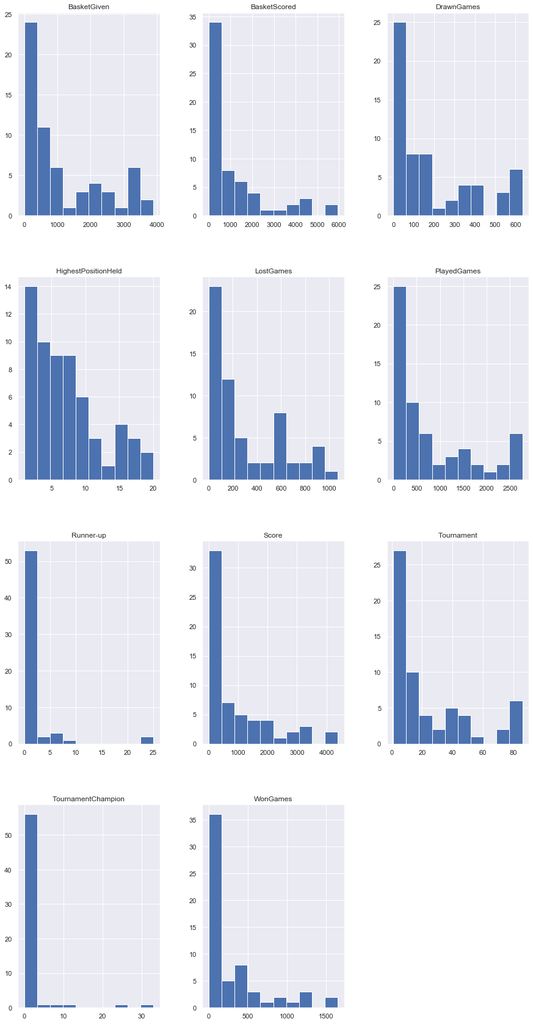

```python
mydata.hist(figsize=(15,30)); # as per the histograms we can see that all are right skeyed
```

```python
mydata.describe(include='all')
```

|  | Team | Tournament | Score | PlayedGames | WonGames | DrawnGames | LostGames | BasketScored | BasketGiven | TournamentChampion | Runner-up | TeamLaunch | HighestPositionHeld |
| --- | --- | --- | --- | --- | --- | --- | --- | --- | --- | --- | --- | --- | --- |
| count | 61 | 61.000000 | 61.000000 | 61.000000 | 61.000000 | 61.000000 | 61.000000 | 61.000000 | 61.000000 | 61.000000 | 61.000000 | 61 | 61.000000 |
| unique | 61 | NaN | NaN | NaN | NaN | NaN | NaN | NaN | NaN | NaN | NaN | 45 | NaN |
| top | Team 40 | NaN | NaN | NaN | NaN | NaN | NaN | NaN | NaN | NaN | NaN | 1929 | NaN |
| freq | 1 | NaN | NaN | NaN | NaN | NaN | NaN | NaN | NaN | NaN | NaN | 10 | NaN |
| mean | NaN | 24.000000 | 901.426230 | 796.819672 | 303.967213 | 188.934426 | 303.754098 | 1140.344262 | 1140.229508 | 1.426230 | 1.409836 | NaN | 7.081967 |
| std | NaN | 26.827225 | 1134.899121 | 876.282765 | 406.991030 | 201.799477 | 294.708594 | 1506.740211 | 1163.710766 | 5.472535 | 4.540107 | NaN | 5.276663 |
| min | NaN | 1.000000 | 0.000000 | 0.000000 | 0.000000 | 0.000000 | 0.000000 | 0.000000 | 0.000000 | 0.000000 | 0.000000 | NaN | 1.000000 |
| 25% | NaN | 4.000000 | 96.000000 | 114.000000 | 34.000000 | 24.000000 | 62.000000 | 153.000000 | 221.000000 | 0.000000 | 0.000000 | NaN | 3.000000 |
| 50% | NaN | 12.000000 | 375.000000 | 423.000000 | 123.000000 | 95.000000 | 197.000000 | 430.000000 | 632.000000 | 0.000000 | 0.000000 | NaN | 6.000000 |
| 75% | NaN | 38.000000 | 1351.000000 | 1318.000000 | 426.000000 | 330.000000 | 563.000000 | 1642.000000 | 1951.000000 | 0.000000 | 0.000000 | NaN | 10.000000 |
| max | NaN | 86.000000 | 4385.000000 | 2762.000000 | 1647.000000 | 633.000000 | 1070.000000 | 5947.000000 | 3889.000000 | 33.000000 | 25.000000 | NaN | 20.000000 |

```python
# from above histogram and decribe function, we can see that all the numerical columns are Right Skeyed
```

```python
corr = mydata.corr() # correlation between the attributes
corr
```

|  | Tournament | Score | PlayedGames | WonGames | DrawnGames | LostGames | BasketScored | BasketGiven | TournamentChampion | Runner-up | HighestPositionHeld |
| --- | --- | --- | --- | --- | --- | --- | --- | --- | --- | --- | --- |
| Tournament | 1.000000 | 0.981441 | 0.998677 | 0.971954 | 0.989387 | 0.949863 | 0.975059 | 0.987828 | 0.589072 | 0.645876 | -0.708071 |
| Score | 0.981441 | 1.000000 | 0.979824 | 0.997240 | 0.958452 | 0.880040 | 0.996656 | 0.944263 | 0.714280 | 0.764278 | -0.669775 |
| PlayedGames | 0.998677 | 0.979824 | 1.000000 | 0.967641 | 0.994053 | 0.956503 | 0.970127 | 0.990129 | 0.574716 | 0.632921 | -0.710876 |
| WonGames | 0.971954 | 0.997240 | 0.967641 | 1.000000 | 0.939844 | 0.852785 | 0.999318 | 0.926234 | 0.752204 | 0.797350 | -0.648628 |
| DrawnGames | 0.989387 | 0.958452 | 0.994053 | 0.939844 | 1.000000 | 0.973156 | 0.942668 | 0.992579 | 0.503472 | 0.566269 | -0.719845 |
| LostGames | 0.949863 | 0.880040 | 0.956503 | 0.852785 | 0.973156 | 1.000000 | 0.859169 | 0.985275 | 0.325462 | 0.393211 | -0.725149 |
| BasketScored | 0.975059 | 0.996656 | 0.970127 | 0.999318 | 0.942668 | 0.859169 | 1.000000 | 0.931548 | 0.743144 | 0.790532 | -0.649455 |
| BasketGiven | 0.987828 | 0.944263 | 0.990129 | 0.926234 | 0.992579 | 0.985275 | 0.931548 | 1.000000 | 0.471824 | 0.533814 | -0.726610 |
| TournamentChampion | 0.589072 | 0.714280 | 0.574716 | 0.752204 | 0.503472 | 0.325462 | 0.743144 | 0.471824 | 1.000000 | 0.971552 | -0.305397 |
| Runner-up | 0.645876 | 0.764278 | 0.632921 | 0.797350 | 0.566269 | 0.393211 | 0.790532 | 0.533814 | 0.971552 | 1.000000 | -0.360408 |
| HighestPositionHeld | -0.708071 | -0.669775 | -0.710876 | -0.648628 | -0.719845 | -0.725149 | -0.649455 | -0.726610 | -0.305397 | -0.360408 | 1.000000 |

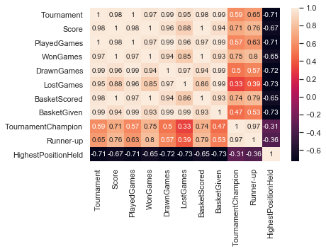

```python
sns.heatmap(corr, annot=True)
```

```python
# from above Correlation and heatmap, we can see that
# Tournament, Score, PlayedGames, WonGames, DrawnGames, LostGames, BasketScored, BasketGiven are correlated
# have direct impact on each other or we can say that these are directly proportional
```

```python
# TournamentChampion & Runner-up are directly related to each other as they have direct impact
# These are also somehwere related to WonGames and BasketScored
```